# D-trees HTML note

Dear all,

Namaste, Salaam and Satsriakal.

Let’s get started.

## LLM assist on D-trees

Let’s start applying what we just learnt about LLM capabilities to D-tree app outputs.

There’re 2 basic outputs of interest for which we seek LLM assistance:

- the d-tree figure itself - analysis and interpretation
- prediction based on d-trees: given a random passenger profile, can the LLM predict outcomes as per the tree?
- there are more outputs we can seek LLM assistance for. This is just illustrative.

Here below is the input picture `titanic dtree.jpg`

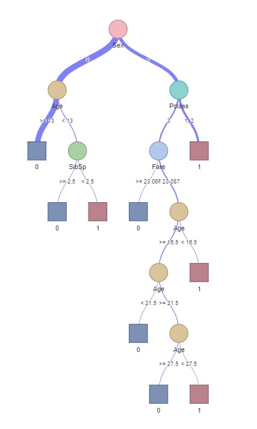

```r
knitr::include_graphics('titanic dtree.jpg')
```

Here is the crafted prompt that includes a brief variable description.

```r
"""
This is a decision tree of the predictors for passenger survival aboard the Titanic vessel.

Outcome variable is 'Survived' (1=yes, 0=No, Y variable).

Passenger characteristics as variables are:
'Pclass' for passenger class {1st, 2nd and 3rd class};
'Sex' {0=Male, 1=Female}, 'Age' in years; 'Fare' in pounds;
'Sibsp' = count of number of siblings or spouse traveling along
'Parch' = count of number opf parents or children traveling along;
'Embarked' = port of embarkment.

Analyze the tree and explain it's main features:
"""
```

Here’s the result I got:

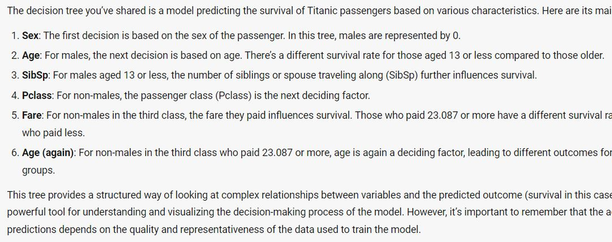

```r
knitr::include_graphics('titanic dtree outp1.jpg')
```

Reg other app outputs we could submit to LLMs for assistance, see this one below:

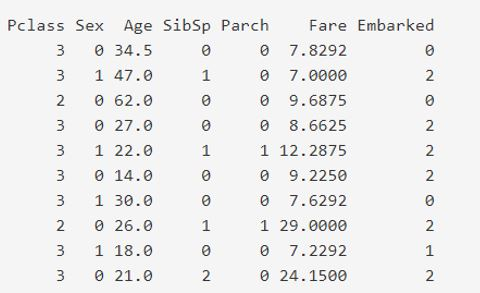

```r
knitr::include_graphics('titanic dtree prediction profiles.jpg')
```

We next ask LLM to predict survival outcomes based on the tree as per the passenger profiles in the above picture. (Note we could have uploaded the file directly into GPT-4).

```r
"""
This is a list of passenger profiles. Evaluate their survival outcomes as per the decision tree before.

Make a table with columns - [1] serial num [2] outcome [3] reasoning
```

Here’s the output I got:

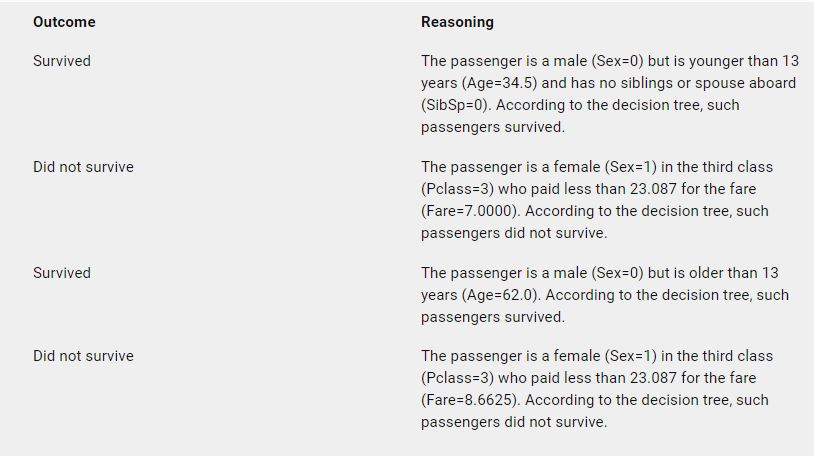

```r
knitr::include_graphics('titanic dtree outp2.jpg')
```

Compare with your responses. Assess response quality.

Big thing abuot LLMs is scale, not just elementary intelligence.

We could do similar with the bank dataset. But that has so many variables.

So, will use image-An to input variable descriptions directly. See below.

```r
"""
This table's first two columns describe variable for a bank dataset on whether or not to give a personal loan.

I ran a decision tree analysis on it.

Read carefully the first 2 columns, ignore the other columns and await further queries.
"""
```

This is the input image:

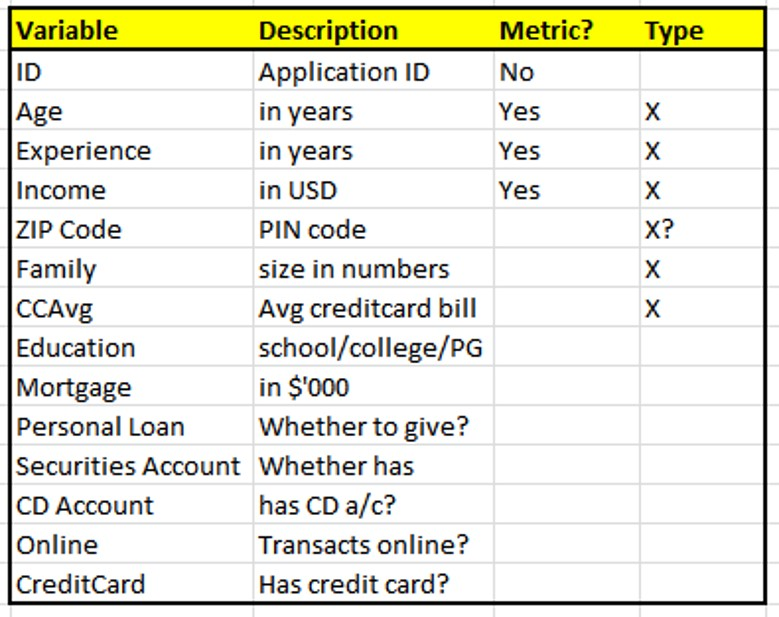

```r
knitr::include_graphics('bank dataset variables.jpg')
```

This below is the prompt and the D=tree for the data.

```r
"""
Analyze this decision tree based on the previous variables and explain the main features of the tree.

Which variables are most important? List in decreasing order of importance.
"""
```

This is the dtree image:

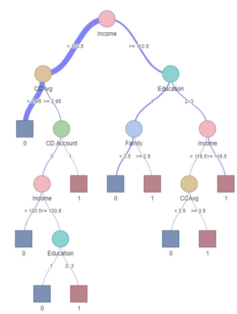

```r
knitr::include_graphics('bank dataset dtree.jpg')
```

This is the output I got:

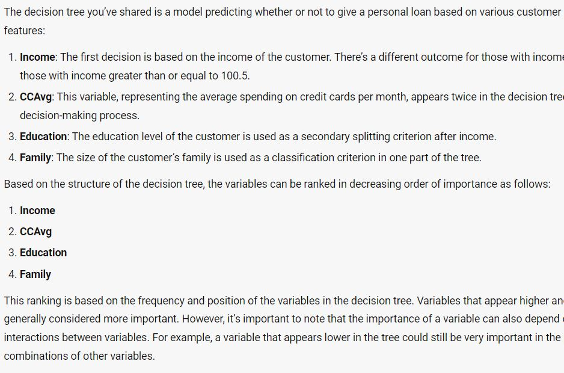

```r
knitr::include_graphics('bank dataset tree outp1.jpg')
```

Sudhir Voleti April 2024